# Programando con R

Ceras Robles, Jose Alexander (código : 17160034)

Condor Melo,Deysy (código : 17160180)

Lara Huapaya, José Alberto (código : 17160206)

Miguel Jurado, Milagros (código : 17160191)

Ramos Castillo,Jacqueline Elizabeth (código : 17160195)

# Ejercicios

## Parte 1

Cargar las variables almacenadas en el archivo Rdata

**1. Calcular los valores numéricos aproximados de:**

**a)** $\frac{0.3.0.15}{0.3.0.15+0.2.0.8+0.5.0.12}$

```r
a<-0.3*0.15/((0.13*0.15)+(0.2*0.8)+(0.5*0.12))
a
```

```
## [1] 0.1878914
```

**b)** $\frac{5^6}{6!}= e^-5$

```r
b<-(5**6/(factorial(6)))*exp(-5)
b
```

```
## [1] 0.1462228
```

Con las funciones nativas de R `factorial` y `exp` se obtuvo como resultado **0.146**

**c)** $\binom {20}{7}$ 0.4<sup>0.7</sup>0.6<sup>13</sup>

```r
c<- (factorial(20)/(factorial(7)*factorial(20-7)))*(0.4**7)*(0.6**13)
c
```

```
## [1] 0.1658823
```

Se utilizo la función nativa de R `factorial` para realizar la operación que dio como resultado **0.166**

**2. Realizar la siguiente suma**

**a)** *1+2+3+…+1000*

```r
Suma_naturales<-function(sn){
  sn*(sn+1)/2
}
Suma_naturales(1000)
```

```
## [1] 500500
```

El ejercicio es una suma de números naturales, se opto por crear una función de acuerdo a la fórmula planteada por *Carl Friedrich Gauss* obteniendo como resultado **500500**.

**b)** *1+2+4+8+…+1024*

```r
nt<-(log(1024/1)/log(2))+1
suma_pg<-function(an,r,a1){
  ((an*r)-a1)/(r-1)
}
suma_pg(1024,2,1)
```

```
## [1] 2047
```

El ejercicio es una suma de una progresión geométrica, inicialmente se obtuvo el valor del número de términos y posteriormente se creó una función obteniendo como resultado **2047**

**3.El vector grupo representa el `grupo` al que pertenece una serie de alumnos**

Se puede cargar la data con la cual se trabajará con `load` o simplemente abriendolo desde la plataforma.

Datos de `grupo`

```r
grupo
```

```
##   [1] "B" "A" "E" "D" "B" "D" "D" "A" "D" "C" "D" "E" "B" "E" "E" "E" "A" "B"
##  [19] "C" "C" "A" "C" "C" "D" "D" "E" "E" "A" "B" "C" "C" "E" "D" "C" "E" "E"
##  [37] "E" "E" "D" "D" "D" "E" "E" "E" "D" "E" "B" "E" "D" "C" "E" "D" "E" "E"
##  [55] "C" "B" "D" "C" "E" "D" "E" "B" "D" "B" "B" "C" "D" "C" "C" "C" "E" "D"
##  [73] "E" "D" "C" "D" "E" "E" "C" "D" "C" "E" "D" "A" "B" "B" "E" "E" "C" "D"
##  [91] "C" "E" "E" "C" "E" "D" "D" "D" "E" "D" "A" "D" "B" "B" "C" "D" "E" "A"
## [109] "E" "E" "A" "C" "E" "D" "A" "D" "D" "C" "E" "E" "E" "D" "A" "E" "E" "E"
## [127] "C" "C" "B" "C" "C" "D" "C" "B" "C" "A" "D" "E" "D" "E" "E" "B" "E" "E"
## [145] "E" "E" "C" "B" "D" "D" "E" "E" "D" "D" "E" "D" "E" "D" "D" "C" "D" "D"
## [163] "D" "C" "E" "D" "E" "C" "E" "B" "C" "C" "C" "D" "D" "B" "D" "B" "E" "C"
## [181] "E" "D" "D" "E" "D" "B" "B" "E" "E" "A" "C" "A"
```

**a)** *¿Cuántos elementos tiene?*

```r
length(grupo)
```

```
## [1] 192
```

Los datos de grupo están en un vector y puede contarse la cantidad de elementos con el comando `length` que devuelve un resultado de **192**.

**b)** *¿En qué posiciones del vector está la letra “A”?*

```r
which(grupo=="A")
```

```
##  [1]   2   8  17  21  28  84 101 108 111 115 123 136 190 192
```

Con el comando `wich` podemos indexar datos con una condicional, aplicamos y obtenemos las posiciones del grupo A.

**4. El vector nota representa la `nota` de un examen de los alumnos que están en los grupos del vector `grupo`.**

Datos de `notas`

```r
nota
```

```
##   [1] 4.9 5.4 5.2 6.8 5.0 6.2 4.4 4.1 4.3 5.5 5.5 4.8 6.4 6.8 5.5 4.7 5.2 6.4
##  [19] 4.8 3.4 4.7 6.0 5.9 5.4 5.3 5.6 6.9 5.6 4.2 4.4 5.8 4.8 6.1 6.2 6.6 5.2
##  [37] 4.6 5.0 2.5 4.0 5.6 4.9 5.4 3.9 4.2 4.7 4.2 5.4 3.7 6.2 5.9 3.7 5.8 2.7
##  [55] 5.6 5.0 2.6 5.0 4.9 3.4 5.9 4.3 6.1 4.5 5.5 3.2 3.2 6.4 4.4 6.0 5.0 5.4
##  [73] 7.0 3.8 4.2 4.7 4.7 5.3 6.8 4.0 7.2 4.8 6.0 4.1 4.5 5.8 2.9 5.0 4.6 4.9
##  [91] 6.8 4.2 6.9 5.7 5.7 6.4 4.4 4.2 4.5 5.8 4.3 3.7 7.4 3.9 5.2 4.9 3.6 5.5
## [109] 6.0 5.0 4.1 4.5 3.1 5.4 4.5 5.3 4.7 6.1 5.2 7.7 5.3 5.0 4.0 5.2 4.0 5.5
## [127] 4.0 5.4 4.6 3.4 6.2 5.7 3.8 4.8 4.0 4.4 5.5 5.9 5.9 5.7 4.9 1.7 5.5 5.9
## [145] 5.5 3.8 5.5 6.0 3.5 5.5 7.5 3.4 5.8 4.7 3.6 4.1 5.0 4.6 3.6 4.7 4.1 5.7
## [163] 5.9 4.7 3.2 5.5 3.0 4.5 5.5 5.9 5.6 6.0 4.4 3.7 4.4 6.8 6.1 4.7 4.2 6.2
## [181] 5.2 5.1 2.9 6.5 4.2 5.4 5.9 6.2 6.3 4.8 5.6 2.9
```

**a)** *¿Cuánto suman todas las notas?*

```r
sum(nota)
```

```
## [1] 962
```

Se usa el comando `sum` para obtener la suma de notas totales siendo está **962**.

**b)** *¿Cuál es la media aritmética de todas las notas?*

```r
mean(nota)
```

```
## [1] 5.010417
```

**c)** *¿En qué posiciones están las notas mayores de 7.0?*

```r
which(nota>7)
```

```
## [1]  81 103 120 151
```

Se usa el comando `wich` y se obtuvo el orden de las notas,

**d)** *Visualiza las notas ordenadas de mayor a menor*

```r
sort(nota,decreasing = T)
```

```
##   [1] 7.7 7.5 7.4 7.2 7.0 6.9 6.9 6.8 6.8 6.8 6.8 6.8 6.6 6.5 6.4 6.4 6.4 6.4
##  [19] 6.3 6.2 6.2 6.2 6.2 6.2 6.2 6.1 6.1 6.1 6.1 6.0 6.0 6.0 6.0 6.0 6.0 5.9
##  [37] 5.9 5.9 5.9 5.9 5.9 5.9 5.9 5.9 5.8 5.8 5.8 5.8 5.8 5.7 5.7 5.7 5.7 5.7
##  [55] 5.6 5.6 5.6 5.6 5.6 5.6 5.5 5.5 5.5 5.5 5.5 5.5 5.5 5.5 5.5 5.5 5.5 5.5
##  [73] 5.5 5.4 5.4 5.4 5.4 5.4 5.4 5.4 5.4 5.3 5.3 5.3 5.3 5.2 5.2 5.2 5.2 5.2
##  [91] 5.2 5.2 5.1 5.0 5.0 5.0 5.0 5.0 5.0 5.0 5.0 5.0 4.9 4.9 4.9 4.9 4.9 4.9
## [109] 4.8 4.8 4.8 4.8 4.8 4.8 4.7 4.7 4.7 4.7 4.7 4.7 4.7 4.7 4.7 4.7 4.6 4.6
## [127] 4.6 4.6 4.5 4.5 4.5 4.5 4.5 4.5 4.4 4.4 4.4 4.4 4.4 4.4 4.4 4.3 4.3 4.3
## [145] 4.2 4.2 4.2 4.2 4.2 4.2 4.2 4.2 4.1 4.1 4.1 4.1 4.1 4.0 4.0 4.0 4.0 4.0
## [163] 4.0 3.9 3.9 3.8 3.8 3.8 3.7 3.7 3.7 3.7 3.6 3.6 3.6 3.5 3.4 3.4 3.4 3.4
## [181] 3.2 3.2 3.2 3.1 3.0 2.9 2.9 2.9 2.7 2.6 2.5 1.7
```

Con el comando `sort` se puede ordenar los datos, y al indicar como `True` al parametro `decreasing` indicamos que debe ser decreciente.

**e)** *¿En qué posición está la nota máxima?*

```r
which(nota==max(nota))
```

```
## [1] 120
```

Con el comando `wich` indexamos la posición y con `max` seleccionamos el mayor valor de las notas, obteniendo como resultado que la mayor nota está en la posición **120**.

**5. A partir de los vectores grupo y nota definidos.**

**a)** *Suma las notas de los 10 primeros alumnos del vector*

Llamamos a las librerias

```r
library(tidyverse)
library(dplyr)
```

```r
head(nota,10)
```

```
##  [1] 4.9 5.4 5.2 6.8 5.0 6.2 4.4 4.1 4.3 5.5
```

```r
sum(head(nota,10))
```

```
## [1] 51.8
```

**b)** *¿Cuantos alumnos hay del grupo C?*

```r
sum(grupo== "C")
```

```
## [1] 39
```

**c)** *¿Cuantos alumnos han aprobado?*

```r
sum(nota>=5.5)
```

```
## [1] 73
```

**d)** *¿Cuantos alumnos del grupo B han aprobado?*

```r
df <- data.frame(grupo,nota)
df02<- as_tibble(df)
nrow (filter(df02, grupo == "B", nota >= 5.5))
```

```
## [1] 9
```

**e)** *¿Que porcentaje de alumnos del grupo C han aprobado?*

```r
notasB <- nota [which( grupo == "B" )] # notas de los alumnos del grupo B
aprobadosC <- nrow (filter(df02, grupo == "C", nota >= 5.5))

which( grupo == "C" )
```

```
##  [1]  10  19  20  22  23  30  31  34  50  55  58  66  68  69  70  75  79  81  89
## [20]  91  94 105 112 118 127 128 130 131 133 135 147 160 164 168 171 172 173 180
## [39] 191
```

```r
notasC <- nota [which( grupo == "C" )] # notas de los alumnos del grupo C
which(notasB >= 5.5)
```

```
## [1]  3  4 10 12 13 18 19 20 23
```

```r
NaprobadosC <- length(which(notasB >= 5.5)) # N° alumnos C aprobados
TotalC <- length(which( grupo == "C") ) # N° total alumnos C
porc <- (aprobadosC/TotalC)*100
print(porc)
```

```
## [1] 51.28205
```

**f)** *¿De que grupos son la maxima y minima notas de toda la muestra?.*

```r
Y<- nota
max(Y) -> Z
Z
```

```
## [1] 7.7
```

```r
min(Y) -> R
R
```

```
## [1] 1.7
```

```r
A <- grupo [which( nota == Z )]
A
```

```
## [1] "E"
```

```r
B <- grupo [which( nota == R )]
B
```

```
## [1] "B"
```

**g) Nota media de los alumnos de grupo A y B, juntos, considerando sólo a los que han aprobado.**

```r
notasA <- nota [which(grupo == "A")] # notas de los alumnos del grupo A
AprobadasA <- notasA[which(notasA >= 5.5)] # Notas aprobadas de A

notasB <- nota [which(grupo == "B")] # notas de los alumnos del grupo B
AprobadasB <- notasB[which(notasB >= 5.5)] # Notas aprobadas de B

c <- c(AprobadasA, AprobadasB)

mean(c)
```

```
## [1] 6.109091
```

**6. Calcula el percentil 66 de las notas de todos los alumnos, y también de los alumnos del grupo C.**

**a)** *Todos los alumnos*

```r
perc <- df$nota
quantile(perc, c(.66))
```

```
## 66%
## 5.5
```

**b)** *Alumnos del grupo C*

```r
GC <- filter(df02, grupo == "C")
GC
```

```
## # A tibble: 39 x 2
##    grupo  nota
##    <chr> <dbl>
##  1 C       5.5
##  2 C       4.8
##  3 C       3.4
##  4 C       6
##  5 C       5.9
##  6 C       4.4
##  7 C       5.8
##  8 C       6.2
##  9 C       6.2
## 10 C       5.6
## # ... with 29 more rows
```

```r
perc2 <- GC$nota
quantile(perc2, c(.66))
```

```
##   66%
## 5.808
```

**7. ¿Que porcentaje, del total de alumnos, tiene una nota menor o igual que la suya? ¿Y qué porcentaje tiene una nota mayor o igual que la suya?**

```r
x<-c(nota)
A <- which(x <= 4.9)
C <- length(A)
A
```

```
##  [1]   1   7   8   9  12  16  19  20  21  29  30  32  37  39  40  42  44  45  46
## [20]  47  49  52  54  57  59  60  62  64  66  67  69  74  75  76  77  80  82  84
## [39]  85  87  89  90  92  97  98  99 101 102 104 106 107 111 112 113 115 117 123
## [58] 125 127 129 130 133 134 135 136 141 142 146 149 152 154 155 156 158 159 160
## [77] 161 164 165 167 168 173 174 175 178 179 183 185 190 192
```

```r
B <- length(nota)
(C*100/B)
```

```
## [1] 46.875
```

```r
x<-c(nota)
A <- which(x >= 4.9)
C <- length(A)
A
```

```
##   [1]   1   2   3   4   5   6  10  11  13  14  15  17  18  22  23  24  25  26
##  [19]  27  28  31  33  34  35  36  38  41  42  43  48  50  51  53  55  56  58
##  [37]  59  61  63  65  68  70  71  72  73  78  79  81  83  86  88  90  91  93
##  [55]  94  95  96 100 103 105 106 108 109 110 114 116 118 119 120 121 122 124
##  [73] 126 128 131 132 137 138 139 140 141 143 144 145 147 148 150 151 153 157
##  [91] 162 163 166 169 170 171 172 176 177 180 181 182 184 186 187 188 189 191
```

```r
B <- length(nota)
(C*100/B)
```

```
## [1] 56.25
```

**8. Realiza el grafico de diagramas de caja de las notas de cada grupo, para poder comparar el nivel de cada uno de ellos.**

```r
N <- c(nota)
N
```

```
##   [1] 4.9 5.4 5.2 6.8 5.0 6.2 4.4 4.1 4.3 5.5 5.5 4.8 6.4 6.8 5.5 4.7 5.2 6.4
##  [19] 4.8 3.4 4.7 6.0 5.9 5.4 5.3 5.6 6.9 5.6 4.2 4.4 5.8 4.8 6.1 6.2 6.6 5.2
##  [37] 4.6 5.0 2.5 4.0 5.6 4.9 5.4 3.9 4.2 4.7 4.2 5.4 3.7 6.2 5.9 3.7 5.8 2.7
##  [55] 5.6 5.0 2.6 5.0 4.9 3.4 5.9 4.3 6.1 4.5 5.5 3.2 3.2 6.4 4.4 6.0 5.0 5.4
##  [73] 7.0 3.8 4.2 4.7 4.7 5.3 6.8 4.0 7.2 4.8 6.0 4.1 4.5 5.8 2.9 5.0 4.6 4.9
##  [91] 6.8 4.2 6.9 5.7 5.7 6.4 4.4 4.2 4.5 5.8 4.3 3.7 7.4 3.9 5.2 4.9 3.6 5.5
## [109] 6.0 5.0 4.1 4.5 3.1 5.4 4.5 5.3 4.7 6.1 5.2 7.7 5.3 5.0 4.0 5.2 4.0 5.5
## [127] 4.0 5.4 4.6 3.4 6.2 5.7 3.8 4.8 4.0 4.4 5.5 5.9 5.9 5.7 4.9 1.7 5.5 5.9
## [145] 5.5 3.8 5.5 6.0 3.5 5.5 7.5 3.4 5.8 4.7 3.6 4.1 5.0 4.6 3.6 4.7 4.1 5.7
## [163] 5.9 4.7 3.2 5.5 3.0 4.5 5.5 5.9 5.6 6.0 4.4 3.7 4.4 6.8 6.1 4.7 4.2 6.2
## [181] 5.2 5.1 2.9 6.5 4.2 5.4 5.9 6.2 6.3 4.8 5.6 2.9
```

```r
A <- nota [which( grupo == "A" )]
A
```

```
##  [1] 5.4 4.1 5.2 4.7 5.6 4.1 4.3 5.5 4.1 4.5 4.0 4.4 4.8 2.9
```

```r
B <- nota [which( grupo == "B" )]
B
```

```
##  [1] 4.9 5.0 6.4 6.4 4.2 4.2 5.0 4.3 4.5 5.5 4.5 5.8 7.4 3.9 4.6 4.8 1.7 6.0 5.9
## [20] 6.8 4.7 5.4 5.9
```

```r
C <- nota [which( grupo == "C" )]
C
```

```
##  [1] 5.5 4.8 3.4 6.0 5.9 4.4 5.8 6.2 6.2 5.6 5.0 3.2 6.4 4.4 6.0 4.2 6.8 7.2 4.6
## [20] 6.8 5.7 5.2 4.5 6.1 4.0 5.4 3.4 6.2 3.8 4.0 5.5 4.7 4.7 4.5 5.6 6.0 4.4 6.2
## [39] 5.6
```

```r
D <- nota [which( grupo == "D" )]
D
```

```
##  [1] 6.8 6.2 4.4 4.3 5.5 5.4 5.3 6.1 2.5 4.0 5.6 4.2 3.7 3.7 2.6 3.4 6.1 3.2 5.4
## [20] 3.8 4.7 4.0 6.0 4.9 6.4 4.4 4.2 5.8 3.7 4.9 5.4 5.3 4.7 5.0 5.7 5.5 5.9 3.5
## [39] 5.5 5.8 4.7 4.1 4.6 3.6 4.1 5.7 5.9 5.5 3.7 4.4 6.1 5.1 2.9 4.2
```

```r
E <- nota [which( grupo == "E" )]
E
```

```
##  [1] 5.2 4.8 6.8 5.5 4.7 5.6 6.9 4.8 6.6 5.2 4.6 5.0 4.9 5.4 3.9 4.7 5.4 5.9 5.8
## [20] 2.7 4.9 5.9 5.0 7.0 4.7 5.3 4.8 2.9 5.0 4.2 6.9 5.7 4.5 3.6 6.0 5.0 3.1 5.2
## [39] 7.7 5.3 5.2 4.0 5.5 5.9 5.7 4.9 5.5 5.9 5.5 3.8 7.5 3.4 3.6 5.0 3.2 3.0 5.5
## [58] 4.2 5.2 6.5 6.2 6.3
```

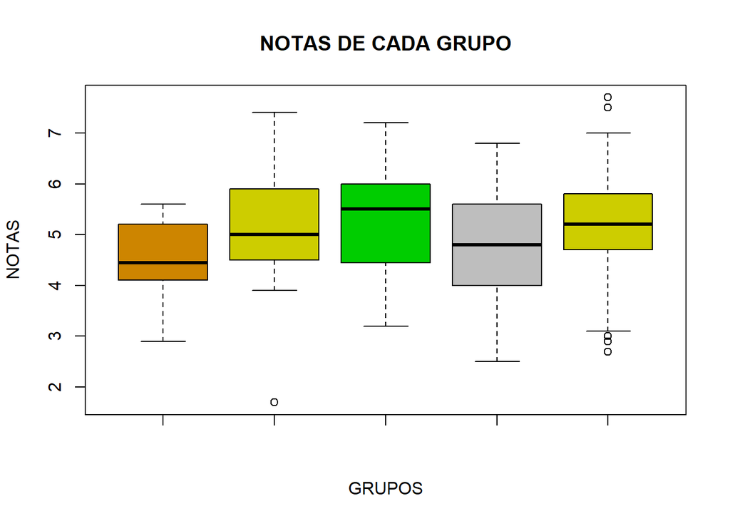

```r
boxplot (A, B, C, D, E, main = "NOTAS DE CADA GRUPO",
         xlab = "GRUPOS", ylab = "NOTAS",
         col = c("orange3", "yellow3", "green3", "grey", "yellow3"))
```

**9. Si la variable conc recoge la concentración de plomo (en ppm) en el aire de cierta zona durante un dia completo.**

**a)** *¿Cuál ha sido la concentración máxima?*

```r
max(conc)
```

```
## [1] 47.34
```

**b)** *¿En cuántos de los muestreos se ha superado la concentración de 40.0 ppm?*

```r
sum(conc > 40.0)
```

```
## [1] 61
```

**c)** *¿Cuál ha sido la concentración media del día?*

```r
mean(conc)
```

```
## [1] 24.07229
```

**d)** *¿Cuáles fueron las 10 mediciones más bajas del día?*

```r
m<-sort(conc)
head(m<-sort(conc), 10)
```

```
##  [1] 0.93 1.07 1.77 2.03 2.58 2.73 2.75 2.88 2.88 2.91
```

**e)** *Si la primera medida fue a las 00:00. ¿A qué hora del día se alcanzó la concentración máxima?*

```r
hora<-seq(as.POSIXct("00:00", format="%H:%M"),
          as.POSIXct("23:59", format="%H:%M"), by="5 min")
h_conc<-data.frame(hora=hora,Medida=conc)
h_conc[max(h_conc$Medida),]
```

```
##                   hora Medida
## 47 2021-07-11 03:50:00  12.91
```

## Parte 2

**1. 1.Graficar los puntos $(1,1),(2,4),(3,6),(4,8),(5,25),(6,36),(7,49),(8,61),(9,81),(10,100)$ en un plano utilizando RStudio.**

Como primer paso tenemos que crear un vector que contengan todos los elementos del eje de las abscisas.

Para crear dicho vector, se pueden realizar de diversas maneras:

1. Digitalizar cada elemento del eje de las abscisas.

```r
x1 <- c(1,2,3,4,5,6,7,8,9,10)
x1
```

```
##  [1]  1  2  3  4  5  6  7  8  9 10
```

2. Establecer una secuencia de números consecutivos utilizando “:”

```r
x2 <- c(1:10)
x2
```

```
##  [1]  1  2  3  4  5  6  7  8  9 10
```

Luego crearemos otro vector que contengan los elementos del eje de las ordenadas. Para crear dicho vector, al no haber una correspondencia entre cada término,se tendrá que digitalizar cada elemento del eje de las ordenadas.

```r
y2 <- c(1,4,6,8,25,36,49,61,81,100)
y2
```

```
##  [1]   1   4   6   8  25  36  49  61  81 100
```

Por último, se procedera a plotearlo, utilizando la funcion “plot”

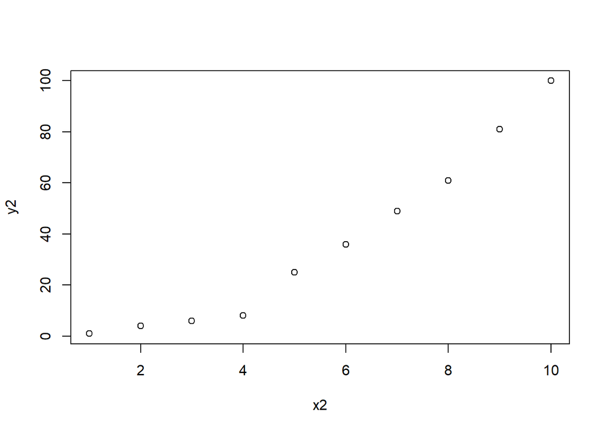

```r
plot(x2,y2)
```

*Descripción: El gráfico representa un plano cartesiano en el que las coordenadas son representadas en función de abscisas y ordenadas (eje x y eje y) y nos muestra una curva ascendente cuadrática con una trayectoria hacia el infinito en el eje de las ordenadas.*

Para borrar el plot actual es de la siguiente manera:

```r
dev.off()
```

Esta función presenta una serie de argumentos, por lo que se pueden colocar los siguientes:

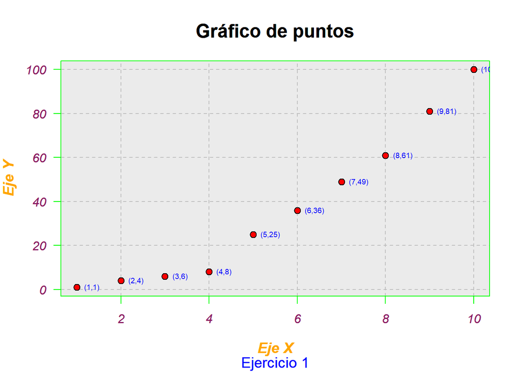

```r
#Para establecer el color del fondo de la caja:

plot.new()

rect(par("usr")[1], par("usr")[3],
     par("usr")[2], par("usr")[4],
     col = "#ebebeb")

par(new = TRUE)


#Para establecer los argumentos de la función "Plot"

plot(x2,y2,
     main="Gráfico de puntos",# Título
     sub = "Ejercicio 1",
     las = 1,                 # Rotar las etiquetas de los ejes de manera horizontal
     xlab = "Eje X",          # Etiqueta del eje x
     ylab = "Eje Y",          # Etiqueta del eje y
     cex.main = 1.5,          # Tamaño del título
     cex.sub = 1.2,           # Tamaño del subtítulo
     cex.lab = 1.2,           # Tamaño de las etiquetas de los ejes X e Y
     cex.axis = 1,            # Tamaño de las etiquetas de los ticks de los ejes
     font.sub = 1,            # Estilo de fuente del título sin formato
     font.main  = 2,          # Estilo de fuente del subtítulo en negrita
     font.axis = 3,           # Estilo de fuente de los ejes X e Y en cursiva
     font.lab  = 4,           # Estilo de fuente de los ticks de los ejes en negrita y cursiva
     pch  = 21,               # Estilo del símbolo de los puntos del grafico
     bg = "red",              # Color de fondo del simbolo
     col = "black",           # Color del borde del simbolo
     cex = 1.2,               # Tamaño del símbolo
     lwd = 1.2,               # Ancho del borde
     col.main = "Black",      # Color del título
     col.sub = "blue",        # Color del subtítulo
     col.lab = "orange",      # Color de las etiqetas de los ejes
     col.axis = "maroon4",    # Color de las etiquetas de los ticks
     fg = "green")            # Color de la caja


#Para agregar una grilla es con la función "Grid"

grid(nx = NULL, ny = NULL,    # Agrega una grilla a los ejes X e Y
     lty = 2,                 # Tipo de línea
     col = "gray",            # Color
     lwd = 1)                 # Ancho de línea
par(new = TRUE)

#Para establecer que las grillas se encuentren por debajo del grafico, lo que haremos es plotear denuevo:

plot(x2,y2,
     main="Gráfico de puntos",# Título
     sub = "Ejercicio 1",
     las = 1,                 # Rotar las etiquetas de los ejes de manera horizontal
     xlab = "Eje X",          # Etiqueta del eje x
     ylab = "Eje Y",          # Etiqueta del eje y
     cex.main = 1.5,          # Tamaño del título
     cex.sub = 1.2,           # Tamaño del subtítulo
     cex.lab = 1.2,           # Tamaño de las etiquetas de los ejes X e Y
     cex.axis = 1,            # Tamaño de las etiquetas de los ticks de los ejes
     font.sub = 1,            # Estilo de fuente del título sin formato
     font.main  = 2,          # Estilo de fuente del subtítulo en negrita
     font.axis = 3,           # Estilo de fuente de los ejes X e Y en cursiva
     font.lab  = 4,           # Estilo de fuente de los ticks de los ejes en negrita y cursiva
     pch  = 21,               # Estilo del símbolo de los puntos del grafico
     bg = "red",              # Color de fondo del simbolo
     col = "black",           # Color del borde del simbolo
     cex = 1.2,               # Tamaño del símbolo
     lwd = 1.2,               # Ancho del borde
     col.main = "Black",      # Color del título
     col.sub = "blue",        # Color del subtítulo
     col.lab = "orange",      # Color de las etiqetas de los ejes
     col.axis = "maroon4",    # Color de las etiquetas de los ticks
     fg = "green")            # Color de la caja


#Para establecer las etiquetas de cada punto se realiza de la siguiente manera:

names <- c("(1,1)","(2,4)","(3,6)","(4,8)","(5,25)","(6,36)","(7,49)","(8,61)","(9,81)","(10,100)")

text(x2, y2,
     labels = names,
     cex = 0.6,               # Tamaño del rotulo de los puntos
     pos = 4,                 # Agrega la posición, en este caso la posición "4" es a la derecha
     col = "blue")            # Agrega el color de los rótulos
```

**2. Ingresar la matriz A en RStudio** $A = \begin{pmatrix} 1 & 2 & 3 \\ 2 & 4 & 6 \\ 3 & 6 & 9 \\ 4 & 8 & 12 \end{pmatrix}$

Hay 3 formas de crear una matriz:

**2.1. Usando la funcion DIM:**

Primero creamos el vector que contiene a todos los elementos de la matriz:

```r
A1<-c(1,2,3,4,2,4,6,8,3,6,9,12)
A1
```

```
##  [1]  1  2  3  4  2  4  6  8  3  6  9 12
```

Luego declaramos las dimensiones de la matriz, en este caso es de 4 filas x 3 columnas:

```r
dim(A1) <- c(4,3)
A1
```

```
##      [,1] [,2] [,3]
## [1,]    1    2    3
## [2,]    2    4    6
## [3,]    3    6    9
## [4,]    4    8   12
```

Si nos damos cuenta, esto funcionaría si el orden de los elementos de la matríz es en el sentido de las columnas, ahora realizaremos la prueba con un vector que contenga los elementos en sentido de las filas:

```r
A2 <-c(1,2,3,2,4,6,3,6,9,4,8,12)
dim(A2) <- c(4,3)
A2
```

```
##      [,1] [,2] [,3]
## [1,]    1    4    9
## [2,]    2    6    4
## [3,]    3    3    8
## [4,]    2    6   12
```

Si nos damos cuenta, no resulta la matriz deseada, por lo que esta función tiene sus limitaciones.

**2.2. Usando la función MATRIZ:**

Para crear una matriz mediante la función matrix y los números del vector A1 con 4 filas y 3 columnas, se usa la siguiente instrucción en R:

```r
A3 <- matrix(A1,nrow = 4,ncol = 3)
A3
```

```
##      [,1] [,2] [,3]
## [1,]    1    2    3
## [2,]    2    4    6
## [3,]    3    6    9
## [4,]    4    8   12
```

En este caso, se ordena por defecto según las columnas. En cambio, si se desea a ingresar los números según las filas, se puede usar:

```r
A4 <- matrix(A1,nrow = 4,ncol = 3,byrow=TRUE)
A4
```

```
##      [,1] [,2] [,3]
## [1,]    1    2    3
## [2,]    4    2    4
## [3,]    6    8    3
## [4,]    6    9   12
```

Como nos damos cuenta, la matriz no es el deseado, por lo que tenemos que usar el vector:

```r
A5 <- matrix(A2,nrow = 4,ncol = 3,byrow=TRUE)
A5
```

```
##      [,1] [,2] [,3]
## [1,]    1    2    3
## [2,]    2    4    6
## [3,]    3    6    9
## [4,]    4    8   12
```

Para observar la clase en mediante la función “CLASS”:

```r
class(A5)
```

```
## [1] "matrix" "array"
```

Para observar los atributos de la matriz, es mediante la función “ATTRIBUTES”

```r
attributes(A5)
```

```
## $dim
## [1] 4 3
```

**2.3. Usando RBIND y CBIND:**

**RBIND:** Esta función crea una matriz en función a las filas,para eso primero creamos 4 vectores que tengan los elementos de cada fila:

```r
(p<-c(1,2,3))
```

```
## [1] 1 2 3
```

```r
(x<-c(2,4,6))
```

```
## [1] 2 4 6
```

```r
(y<-c(3,6,9))
```

```
## [1] 3 6 9
```

```r
(z<-c(4,8,12))
```

```
## [1]  4  8 12
```

Por consiguiente, se crea la matriz A6 a partir de los vectores p,x,y,z utilizando la función RBIND. En R:

```r
A6 <- rbind(p,x,y,z)
A6
```

```
##   [,1] [,2] [,3]
## p    1    2    3
## x    2    4    6
## y    3    6    9
## z    4    8   12
```

**CBIND:** Esta función crear una matriz en función a las columnas,para eso primero creamos 3 vectores que tengan los elementos de cada columna:

```r
(a <- c(1,2,3,4))
```

```
## [1] 1 2 3 4
```

```r
(b <- c(2,4,6,8))
```

```
## [1] 2 4 6 8
```

```r
(c <- c(3,6,9,12))
```

```
## [1]  3  6  9 12
```

Por consiguiente, se crea la matriz A7 a partir de los vectores a,b,c utilizando la función CBIND. En R:

```r
A7 <- cbind(a,b,c)
A7
```

```
##      a b  c
## [1,] 1 2  3
## [2,] 2 4  6
## [3,] 3 6  9
## [4,] 4 8 12
```

**3. Ingresar la matriz identidad de tamaño 3** $I = \begin{pmatrix} 1 & 0 & 0 \\ 0 & 1 & 0 \\ 0 & 0 & 1 \end{pmatrix}$

Una forma de crear una matriz identidad de tamaño 3 es creando un vector que contengan los elementos y usando cualquiera de las 3 formas de crear una matriz mencionadas anteriormente, se obtendrá el resultado:

```r
I1 <- matrix(c(1,0,0,0,1,0,0,0,1),nrow = 3,ncol = 3)
I1
```

```
##      [,1] [,2] [,3]
## [1,]    1    0    0
## [2,]    0    1    0
## [3,]    0    0    1
```

Sin embargo, existe una función que te crea una matriz identidad de manera rápida, esta es la función diag():

```r
I2 <- diag(3)
I2
```

```
##      [,1] [,2] [,3]
## [1,]    1    0    0
## [2,]    0    1    0
## [3,]    0    0    1
```

Si se desea colocar que en la diagonal aparezca un número específico, se realiza la siguiente estructura:

```r
I3 <- diag(1,3,3) #Primero se especifica el elemento que irá en la diagonal de la matriz, luego se especifica el número de filas y por último, el número de columnas.

I3
```

```
##      [,1] [,2] [,3]
## [1,]    1    0    0
## [2,]    0    1    0
## [3,]    0    0    1
```

**4. Crea una función que cree una matriz nula ingresando las dimensiones**

Primero crearemos la matriz nula a partir de un número determinado de filas y columnas:

```r
I0 <-diag(0,5,5)
I0
```

```
##      [,1] [,2] [,3] [,4] [,5]
## [1,]    0    0    0    0    0
## [2,]    0    0    0    0    0
## [3,]    0    0    0    0    0
## [4,]    0    0    0    0    0
## [5,]    0    0    0    0    0
```

Luego, crearemos la función que tenga como parámetros al número de filas y columnas:

```r
I0 <-function(a,b){
        I <-diag(0,a,b)
        return(I)
}
```

Por ejemplo, se pide crear una matriz nula que contegan 3 filas y 5 columnas:

```r
I0(3,5)
```

```
##      [,1] [,2] [,3] [,4] [,5]
## [1,]    0    0    0    0    0
## [2,]    0    0    0    0    0
## [3,]    0    0    0    0    0
```

Otros ejemplos:

```r
I0(10,2)
```

```
##       [,1] [,2]
##  [1,]    0    0
##  [2,]    0    0
##  [3,]    0    0
##  [4,]    0    0
##  [5,]    0    0
##  [6,]    0    0
##  [7,]    0    0
##  [8,]    0    0
##  [9,]    0    0
## [10,]    0    0
```

```r
I0(2,5)
```

```
##      [,1] [,2] [,3] [,4] [,5]
## [1,]    0    0    0    0    0
## [2,]    0    0    0    0    0
```

```r
I0(5,6)
```

```
##      [,1] [,2] [,3] [,4] [,5] [,6]
## [1,]    0    0    0    0    0    0
## [2,]    0    0    0    0    0    0
## [3,]    0    0    0    0    0    0
## [4,]    0    0    0    0    0    0
## [5,]    0    0    0    0    0    0
```

**5. Modificar la matriz `diag(4)`, para que se parezca a la matriz B** $B = \begin{pmatrix} 0 & 0 & 0 & 0 \\ 0 & 2 & 0 & 0 \\ 0 & 0 & 3 & 0 \\ 0 & 0 & 0 & 4 \end{pmatrix}$

Como primer paso, crearemos la matriz diag(4):

```r
B <- diag(4)
B
```

```
##      [,1] [,2] [,3] [,4]
## [1,]    1    0    0    0
## [2,]    0    1    0    0
## [3,]    0    0    1    0
## [4,]    0    0    0    1
```

Luego realizaremos la manipulación de los elementos de dicha matriz:

```r
B[1,1]=0
B[2,2]=2
B[3,3]=3
B[4,4]=4
B
```

```
##      [,1] [,2] [,3] [,4]
## [1,]    0    0    0    0
## [2,]    0    2    0    0
## [3,]    0    0    3    0
## [4,]    0    0    0    4
```

**6. Obtener la matriz transpuesta de A (ejercicio 2)**

Primero creamos la matriz de ejercicio por cualquiera de los métodos mencionados:

```r
A <- matrix(c(1,2,3,4,2,4,6,8,3,6,9,12),nrow = 4,ncol = 3)
A
```

```
##      [,1] [,2] [,3]
## [1,]    1    2    3
## [2,]    2    4    6
## [3,]    3    6    9
## [4,]    4    8   12
```

Para calcular la matriz transpuesta es con la función t():

```r
t(A)
```

```
##      [,1] [,2] [,3] [,4]
## [1,]    1    2    3    4
## [2,]    2    4    6    8
## [3,]    3    6    9   12
```

**7. Realizar las siguientes operaciones $A + B$, $A - B$, $3B$ y $AB$**

Sean las matrices A y B:

```r
A
```

```
##      [,1] [,2] [,3]
## [1,]    1    2    3
## [2,]    2    4    6
## [3,]    3    6    9
## [4,]    4    8   12
```

```r
B
```

```
##      [,1] [,2] [,3] [,4]
## [1,]    0    0    0    0
## [2,]    0    2    0    0
## [3,]    0    0    3    0
## [4,]    0    0    0    4
```

1. Suma o diferencia de matrices:

Es importante que ambas tengan las mismas dimensiones (mismo número de filas y mismo número de columnas):

```r
dim(A)==dim(B)
```

```
## [1]  TRUE FALSE
```

Como observamos, no se podria realizar una suma ni resta, ya que sus dimensiones no son iguales.

2. Multiplicación de una matriz por un escalar:

Para multiplicar una matriz por un número escalar es de la siguiente manera:

```r
3*B
```

```
##      [,1] [,2] [,3] [,4]
## [1,]    0    0    0    0
## [2,]    0    6    0    0
## [3,]    0    0    9    0
## [4,]    0    0    0   12
```

3. Multiplicacion de matrices:

Para el producto o multiplicación matricial, se debe considerar que la primera matriz debe ser de dimensión 𝑚 × 𝑛 y la segunda, de 𝑛 × 𝑝. Es decir, la primera matriz debe tener el número de columnas igual al número de filas de la segunda matriz.

```r
dim(A)==dim(B)
```

```
## [1]  TRUE FALSE
```

Como observamos, no se podría realizar una multiplicación de matrices, dado que sus dimensiones no cumplen con el requisito del ítem anterior.

**8. Crea una función para calcular $P^6$** $P = \begin{pmatrix} 1 & 2 & 3 \\ -2 & 4 & -2 \\ 1 & 0 & 1 \end{pmatrix}$

Primero crearemos la matriz P:

```r
P0 <-matrix(c(1,2,3,-2,4,-2,1,0,1),nrow = 3,ncol = 3,byrow = TRUE)
P0
```

```
##      [,1] [,2] [,3]
## [1,]    1    2    3
## [2,]   -2    4   -2
## [3,]    1    0    1
```

**Potencia de una matriz:**

En R base se puede realizar el cálculo de la potencia de una matriz usando el operador %*% :

Para calcular la matriz elevada al cuadrado es de la siguiente manera:

```r
P0 %*% P0
```

```
##      [,1] [,2] [,3]
## [1,]    0   10    2
## [2,]  -12   12  -16
## [3,]    2    2    4
```

Pero resultaría tedioso realizar este procedimientos para potencias elevadas a números grandes. No existe una función en R base que calcule la potencia de una matriz, pero se puede realizar de dos maneras usando paquetes específicos:

**8.1. Usando el operador %^% del paquete EXPM:**

Primero instalamos el paquete *EXPM*:

```r
#install.packages("expm")
library(expm)
```

Luego se realiza la siguiente estructura:

```r
#Para calcular la matriz elevada al cuadrado:
P0 %^% 2
```

```
##      [,1] [,2] [,3]
## [1,]    0   10    2
## [2,]  -12   12  -16
## [3,]    2    2    4
```

**8.2. Usando la función MATRIX.POWER del paquete MATRIXCALC:**

Primero instalamos el paquete *MATRIXCALC*:

```r
#install.packages("matrixcalc")
library(matrixcalc)
```

Luego se realiza la siguiente estructura:

```r
#Para calcular la matriz elevada al cuadrado:
matrix.power(P0,2)
```

```
##      [,1] [,2] [,3]
## [1,]    0   10    2
## [2,]  -12   12  -16
## [3,]    2    2    4
```

*NOTA:La matriz debe ser cuadrada para calcular la potencia, ya que el número de columnas debe ser igual al número de filas para realizar los cálculos.*

Como último paso, crearemos una función que tenga como parámetro la potencia, utilizando cualquiera de los dos métodos mencionados anteriormente:

```r
P <- function(a){
        P0 <-matrix(c(1,2,3,-2,4,-2,1,0,1),nrow = 3,ncol = 3,byrow = TRUE)
        P1<-matrix.power(P0,a)
        return(P1)
}

P(6)
```

```
##       [,1]  [,2]  [,3]
## [1,] -1792    24 -2824
## [2,]  -464 -2416 -1344
## [3,]  -648   440  -912
```

**9. Resolver el sistema de ecuaciones**

$3x - y + z = -1\\9x - 2y + z = -9\\3x + y - 2z = -9$

El siguiente sistema se resolverá mediante operaciones fila. Al ordenar de forma matricial, se obtiene el siguiente resultado:

$$

$$\begin{pmatrix} A \end{pmatrix}$$
$$\begin{pmatrix} X \end{pmatrix}$$

=

$$\begin{pmatrix} B \end{pmatrix}$$

$$

$$

$$\begin{pmatrix}
3 & -1 & 1 \\
9 & -2 & 1 \\
3 & 1 & -2 \\
\end{pmatrix}$$
$$\begin{pmatrix}
x \\
y \\
z \\
\end{pmatrix}$$
=
$$\begin{pmatrix}
-1 \\
-9 \\
-9 \\
\end{pmatrix}$$

$$ Entonces como primer paso crearemos las matrices “A” y “B”:

Creación de la matriz A:

```r
A <- matrix(c(3,-1,1,9,-2,1,3,1,-2),3,3,byrow=T)
A
```

```
##      [,1] [,2] [,3]
## [1,]    3   -1    1
## [2,]    9   -2    1
## [3,]    3    1   -2
```

Creación de la matriz B:

```r
B <- matrix(c(-1,-9,-9),3,1)
B
```

```
##      [,1]
## [1,]   -1
## [2,]   -9
## [3,]   -9
```

Por consiguiente, concatenaremos las matrices “A” y “B” para obtener una nueva matriz denominada “AB”:

```r
AB <- cbind(A,B)
AB
```

```
##      [,1] [,2] [,3] [,4]
## [1,]    3   -1    1   -1
## [2,]    9   -2    1   -9
## [3,]    3    1   -2   -9
```

Para hallar 𝑥, 𝑦, z es necesario que las tres primeras columnas formen una matriz identidad de 3 x 3. La última columna representará el vector de soluciones. Para llegar a dicha solución, se realizarán las operaciones en fila:

Como primera operación, se debe obtener la unidad en el primer elemento de la fila 1, para eso dividimos toda la primera fila entre 3:

```r
AB[1,] <- AB[1,]/3
AB
```

```
##      [,1]       [,2]       [,3]       [,4]
## [1,]    1 -0.3333333  0.3333333 -0.3333333
## [2,]    9 -2.0000000  1.0000000 -9.0000000
## [3,]    3  1.0000000 -2.0000000 -9.0000000
```

Aplicando la misma lógica, para obtener que toda la primera columna tenga la unidad, se debe dividir dichos elementos entre su misma cantidad:

```r
AB[2,] <- AB[2,]/9
AB
```

```
##      [,1]       [,2]       [,3]       [,4]
## [1,]    1 -0.3333333  0.3333333 -0.3333333
## [2,]    1 -0.2222222  0.1111111 -1.0000000
## [3,]    3  1.0000000 -2.0000000 -9.0000000
```

```r
AB[3,] <- AB[3,]/3
AB
```

```
##      [,1]       [,2]       [,3]       [,4]
## [1,]    1 -0.3333333  0.3333333 -0.3333333
## [2,]    1 -0.2222222  0.1111111 -1.0000000
## [3,]    1  0.3333333 -0.6666667 -3.0000000
```

El siguiente paso es obtener un valor “cero” en la posición [2,1], para esto restamos la segunda fila con la primera fila:

```r
AB[2,] <- AB[2,]-AB[1,]
AB
```

```
##      [,1]       [,2]       [,3]       [,4]
## [1,]    1 -0.3333333  0.3333333 -0.3333333
## [2,]    0  0.1111111 -0.2222222 -0.6666667
## [3,]    1  0.3333333 -0.6666667 -3.0000000
```

De igual forma, para obtener un valor “cero” en la posición [3,1], se tiene que restar tercera fila con la primera fila:

```r
AB[3,] <- AB[3,]-AB[1,]
AB
```

```
##      [,1]       [,2]       [,3]       [,4]
## [1,]    1 -0.3333333  0.3333333 -0.3333333
## [2,]    0  0.1111111 -0.2222222 -0.6666667
## [3,]    0  0.6666667 -1.0000000 -2.6666667
```

El siguiente procedimiento será determinar la unidad en la posición de la diagonal principal de la matriz para formar la matriz identidad, para eso dividimos la fila 2 entre el valor de la posición [2,2]:

```r
AB[2,] <- AB[2,]/AB[2,2]
AB
```

```
##      [,1]       [,2]       [,3]       [,4]
## [1,]    1 -0.3333333  0.3333333 -0.3333333
## [2,]    0  1.0000000 -2.0000000 -6.0000000
## [3,]    0  0.6666667 -1.0000000 -2.6666667
```

Aprovechando el valor de la posición [2,2], se puede utilizar para determinar el valor cero de la posición [3,2], ya que a la segunda fila se le puede multiplicar por dicha posición, con el objetivo de aplicarle una resta y obtener el valor 0 para la posición [3,2]:

```r
AB[3,] <- AB[3,]-(AB[2,]*AB[3,2])
AB
```

```
##      [,1]       [,2]       [,3]       [,4]
## [1,]    1 -0.3333333  0.3333333 -0.3333333
## [2,]    0  1.0000000 -2.0000000 -6.0000000
## [3,]    0  0.0000000  0.3333333  1.3333333
```

Luego dividimos la fila 3 entre el valor de la posición [3,3] para hallar la unidad de dicha posición:

```r
AB[3,] <- AB[3,]/AB[3,3]
AB
```

```
##      [,1]       [,2]       [,3]       [,4]
## [1,]    1 -0.3333333  0.3333333 -0.3333333
## [2,]    0  1.0000000 -2.0000000 -6.0000000
## [3,]    0  0.0000000  1.0000000  4.0000000
```

Luego para completar el valor “cero” de la posición [2,3], se aprovechará el valor de la unidad de la columna 2, sumando la fila 2 con el producto de la fila 3 con el número escalar 2, ya que se nota que la posición [2,3] es el doble de la posición [3,3]:

```r
AB[2,] <- AB[2,]+(AB[3,]*2)
AB
```

```
##      [,1]       [,2]      [,3]       [,4]
## [1,]    1 -0.3333333 0.3333333 -0.3333333
## [2,]    0  1.0000000 0.0000000  2.0000000
## [3,]    0  0.0000000 1.0000000  4.0000000
```

Aplicando el mismo procedimiento del paso anterior, se puede obtener el valor “cero” en la posición [1,2], aprovechando la unidad de la posición [2,2]:

```r
AB[1,] <- AB[1,]-(AB[2,]*AB[1,2])
AB
```

```
##      [,1] [,2]      [,3]      [,4]
## [1,]    1    0 0.3333333 0.3333333
## [2,]    0    1 0.0000000 2.0000000
## [3,]    0    0 1.0000000 4.0000000
```

De la misma manera, se realiza el mismo procedimiento para calcular el valor “cero” de la posición [1,3]:

```r
AB[1,] <- AB[1,]-(AB[3,]*AB[1,3])
AB
```

```
##      [,1] [,2] [,3] [,4]
## [1,]    1    0    0   -1
## [2,]    0    1    0    2
## [3,]    0    0    1    4
```

*Se observa que las tres primeras columnas forman una matriz identidad 3 × 3. Esto quiere decir que la solución es 𝑥 = -1, 𝑦 = 2, 𝑧 = 4.*

Para extraer la matriz de la solución del sistema, se creará una variable “X” que representará dicha matriz:

```r
X <- AB[,4]
X
```

```
## [1] -1  2  4
```

**FUNCIÓN SOLVE**: Esta función genérica resuelve la ecuación a% *% x = b para x, donde b puede ser un vector o una matriz.

Para demostrar que la matriz 3 x 3 obtenida es invertible, se le debe aplicar la función “Solve”:

```r
XX <- solve(A,B)
XX
```

```
##      [,1]
## [1,]   -1
## [2,]    2
## [3,]    4
```

Como se puede observar, una manera fácil de resolver el sistema es mediante la función “Solve”. Así mismo, ambos resultados son los mismos, por lo que se comprueba que las operaciones anteriores son correctas.

**10. Utilizando la ayuda de R, investigue para qué sirven las funciones `eigen()` y `det()`**

**Función eigen()**: Calcula autovalores y autovectores de matrices numéricas (dobles, enteras, lógicas) o complejas, para entenderlo, tenemos que saber sobre los Análisis de Comoponentes Principales (PCA)

*Análisis de Componentes Principales (PCA)*:es un método estadístico que permite simplificar la complejidad de espacios muestrales con muchas dimensiones a la vez que conserva su información.

El método de PCA permite por lo tanto “condensar” la información aportada por múltiples variables en solo unas pocas componentes.

**b) Eigenvalues (Autovalores):** Cuando se multiplica una matriz por alguno de sus eigenvectors se obtiene un múltiplo del vector original, es decir, el resultado es ese mismo vector multiplicado por un número. Al valor por el que se multiplica el eigenvector resultante se le conoce como eigenvalue. A todo eigenvector le corresponde un eigenvalue y viceversa.

Entonces la función eigen() calcula ambos y los almacena en una lista bajo el nombre de vectors y values. Los eigenvalues se devuelven en orden decreciente y los eigenvectors (estandarizados) se ordenan de izquierda a derecha acorde a sus eigenvalues asociados.

Por ejemplo tenemos la siguiente matriz:

```r
x<-cbind(c(6,9), c(4,2))
x
```

```
##      [,1] [,2]
## [1,]    6    4
## [2,]    9    2
```

Para determinar los autovalores y autovectores, se aplica la función eigen():

```r
eigen(x)
```

```
## eigen() decomposition
## $values
## [1] 10.324555 -2.324555
##
## $vectors
##           [,1]       [,2]
## [1,] 0.6790224 -0.4331018
## [2,] 0.7341175  0.9013450
```

**Función det():** Calcula el determinante de una matriz. El determinante es una función genérica que devuelve por separado el módulo del determinante, opcionalmente en la escala logarítmica, y el signo del determinante.

Para calcular el determinante de una matriz, estás deben ser cuadradas, es decir, deben tener el mismo número de filas y el mismo número de columnas.

Por ejemplo, tenemos la matriz siguiente:

```r
D<-matrix(c(1,5,3,2),2,2)
D
```

```
##      [,1] [,2]
## [1,]    1    3
## [2,]    5    2
```

Calculando el determinante de la matriz cuadrada:

```r
det(D)
```

```
## [1] -13
```

**11. Considerando las matrices**

$$

B=
$$\begin{pmatrix}
1 & 2 & 3 & 4 & 5 \\
2 & 4 & 6 & 8 & 10 \\
3 & 6 & 9 & 12 & 15 \\
4 & 8 & 12 & 16 & 20 \\
5 & 10 & 15 & 20 & 25 \\
6 & 12 & 18 & 24 & 30 \\
7 & 14 & 21 & 28 & 35 \\
8 & 16 & 24 & 32 & 40 \\
9 & 18 & 27 & 36 & 45 \\
10 & 20 & 30 & 40 & 50
\end{pmatrix}$$
A =
$$\begin{pmatrix}
0 & 1 & 0 & 1 & 0 \\
1 & 0 & 1 & 0 & 1 \\
0 & 1 & 0 & 1 & 0 \\
0 & 1 & 0 & 0 & 1 \\
1 & 0 & 1 & 1 & 0 \\
\end{pmatrix}$$

$$

Calcular $A \cdot B - A B^t$

**Creamos la matriz A:**

En esta ocasión se creará vectores de la misma longitud que contengan 0 y 1:

```r
(a <- c(0,0,0))
```

```
## [1] 0 0 0
```

```r
(b <- c(1,1,1))
```

```
## [1] 1 1 1
```

El objetivo es combinar dichos vectores para crear 2 vectores que contengan los elementos de los originales intercalados.

```r
v1 <- as.numeric(rbind(a,b))
v1
```

```
## [1] 0 1 0 1 0 1
```

```r
v2 <- as.numeric(rbind(b,a))
v2
```

```
## [1] 1 0 1 0 1 0
```

Luego eliminaremos la posición “x” de los vectores, con el objetivo de obtener las filas de la matriz A:

Para obtener la primera y tercera fila de la matriz A:

```r
v3 <- v1[-6]
v3
```

```
## [1] 0 1 0 1 0
```

Para obtener la segunda fila de la matriz A:

```r
v4 <- v2[-6]
v4
```

```
## [1] 1 0 1 0 1
```

Para obtener la cuarta fila de la matriz A:

```r
v5 <- v1[-4]
v5
```

```
## [1] 0 1 0 0 1
```

Para obtener la quinta fila de la matriz A:

```r
v6 <- v2[-4]
v6
```

```
## [1] 1 0 1 1 0
```

Por último, unimos los vectores formados en una matriz:

```r
A <- matrix(c(v3,v4,v3,v5,v6),5,5,byrow=T)
A
```

```
##      [,1] [,2] [,3] [,4] [,5]
## [1,]    0    1    0    1    0
## [2,]    1    0    1    0    1
## [3,]    0    1    0    1    0
## [4,]    0    1    0    0    1
## [5,]    1    0    1    1    0
```

**Creamos la matriz B:**

Se creará a partir de secuencias:

```r
B <- matrix(c(1:10,seq(2,20,by=2),seq(3,30,by=3),seq(4,40,by=4),seq(5,50,by=5)),10,5)
B
```

```
##       [,1] [,2] [,3] [,4] [,5]
##  [1,]    1    2    3    4    5
##  [2,]    2    4    6    8   10
##  [3,]    3    6    9   12   15
##  [4,]    4    8   12   16   20
##  [5,]    5   10   15   20   25
##  [6,]    6   12   18   24   30
##  [7,]    7   14   21   28   35
##  [8,]    8   16   24   32   40
##  [9,]    9   18   27   36   45
## [10,]   10   20   30   40   50
```

**Calculando: $A \cdot B - A B^t$**

Primero veremos si las dimensiones de cada matriz:

```r
dim(A)
```

```
## [1] 5 5
```

```r
dim(B)
```

```
## [1] 10  5
```

*Para el producto o multiplicación matricial, se debe considerar que la primera matriz debe ser de dimensión 𝑚 × 𝑛 y la segunda, de 𝑛 × 𝑝. Es decir, la primera matriz debe tener el número de columnas igual al número de filas de la segunda matriz.En este caso no cumple con lo anterior, por lo que no se podrá realizar la operación pedida.*

**12. Considere** $\hat\beta = (X^t \cdot X)^{-1} \cdot X^t \cdot Y$

Determine la matriz $\hat\beta$

$$

x=
$$\begin{pmatrix}1 & 1\\ 1 & -1\\ 1 & 0\\ 1 & 1\\ 1 & 2\\ \end{pmatrix}$$
y =
$$\begin{pmatrix}0\\0\\1\\1\\3\\\end{pmatrix}$$

$$

**Creamos la matriz x:**

```r
x <- matrix(c(rep(1,5),1,-1,0,1,2),5,2)
x
```

```
##      [,1] [,2]
## [1,]    1    1
## [2,]    1   -1
## [3,]    1    0
## [4,]    1    1
## [5,]    1    2
```

**Creamos la matriz y:**

```r
y <- matrix(c(0,0,1,1,3),5,1)
y
```

```
##      [,1]
## [1,]    0
## [2,]    0
## [3,]    1
## [4,]    1
## [5,]    3
```

Calculando: $\hat\beta = (X^t \cdot X)^{-1} \cdot X^t \cdot Y$

```r
b <- ((solve(t(x)%*%x)%*%t(x))%*%y)
b
```

```
##           [,1]
## [1,] 0.5384615
## [2,] 0.7692308
```

**13) El vector `co2` contiene medidas de CO2 en la atmósfera, en unidades de ppm, durante el periodo 1959-1997. El vector `year` contiene sus años correspondientes.**

```r
data(co2)
means = aggregate(co2, FUN=mean)
year = as.vector(time(means))
co2 = as.vector(means)
```

- **Calcular un vector de diferencias de *CO2* entre años consecutivos, que sería:**
- *CO2* en 1960 menos *CO2* en 1959
- *CO2* en 1961 menos *CO2* en 1960 y así sucesivamente

```r
dato<-data.frame(year=year,nivel=round(co2,1)) %>% mutate(rest=c(nivel[2:39],0)) %>% mutate(Diferencia=rest-nivel)
vect<-dato[1:38,4]
vect
```

```
##  [1] 0.9 0.8 0.8 0.5 0.7 0.4 1.3 0.8 0.9 1.6 1.0 0.7 1.1 2.2 0.6 0.9 1.0 1.7 1.6
## [20] 1.4 1.8 1.3 1.2 1.6 1.6 1.5 1.3 1.8 2.5 1.5 1.2 1.5 0.8 0.7 1.9 2.0 1.8 1.1
```

- **Crear un plot con lineas y puntos mostrando las diferencias consecutivas de *CO2* en función del tiempo (1960, 1961, etc), en *negrita***

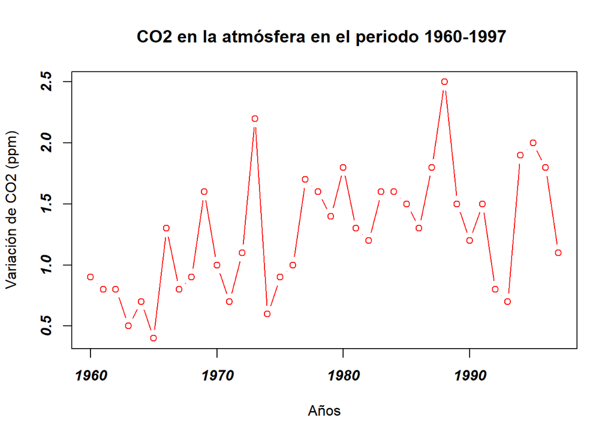

*Descripción: El gráfico representa la variación anual del CO2 a través de un periódo de tiempo desde el año 1959 hasta el año 1997 donde se establece un promedio mensual de esos años y se le compara con la cantidad de ppm de CO2 muestreadas en cada año, resumidamente por décadas desde 1960 a 1970 presenta los valores más bajos de concentración de CO2, desde los años 1970 a 1980 nos muestra una variación muy distintivas siendo muy irregular pero en relación a la década pasada presenta una mayor alza de concentraciones de CO2 y en la década de 1980 a 1990 existe mayor cantidad de CO2 que en otras décadas pasadas, además de el mayor pico de concentracion de ppm; por último en la decada de 1990 a más hubo una baja considerable respecto a la anterior y una baja distinguible de concentración de ppm.*

- **La diferencia de concentración de *CO2* entre 2020 y 2019 fue igual a 2.64. Agregar un punto rojo representando esa diferencia al plot ya creado (usar una forma diferente , como `pch=4`**

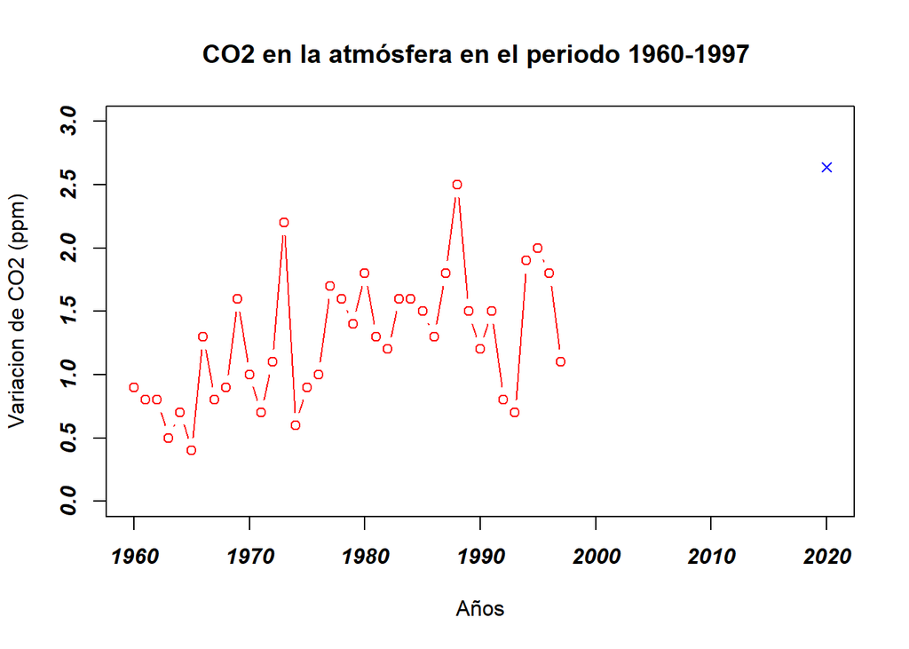

*Descripción: Respecto a la anterior figura muestra un dato del año 2020 donde esta la más alta concentración incluso mas que las décadas pasadas sobre las concentraciones de ppm, siendo este indicador que despues de la última década del anterior gráfico existió una laza o incremento en las cantidades de ppm de CO2 muestreadas.*

**14) Lee el archivo `rainfall.csv` como un `data.frame**

```r
data_R<-read.csv("https://raw.githubusercontent.com/ryali93/ProgramacionR/master/data/rainfall.csv")
head(data_R)
```

```
##      num altitude sep oct nov dec jan feb mar apr may              name
## 1 110050       30 1.2  33  90 117 135 102  61  20 6.7 Kfar Rosh Hanikra
## 2 110351       35 2.3  34  86 121 144 106  62  23 4.5              Saar
## 3 110502       20 2.7  29  89 131 158 109  62  24 3.8             Evron
## 4 111001       10 2.9  32  91 137 152 113  61  21 4.8       Kfar Masrik
## 5 111650       25 1.0  27  78 128 136 108  59  21 4.7     Kfar Hamakabi
## 6 120202        5 1.5  27  80 127 136  95  49  19 2.7        Haifa Port
##      x_utm   y_utm
## 1 696533.1 3660837
## 2 697119.1 3656748
## 3 696509.3 3652434
## 4 696541.7 3641332
## 5 697875.3 3630156
## 6 687006.2 3633330
```

- Calcula e imprime un vector con los nombres de las estaciones donde al menos uno de los meses tiene una precipitación superior a 180mm *

```r
library(tidyr)
library(dplyr)
r_ga<-gather(data = data_R, key = "Meses", value = "precipitacion", 3:11)
head(r_ga)
```

```
##      num altitude              name    x_utm   y_utm Meses precipitacion
## 1 110050       30 Kfar Rosh Hanikra 696533.1 3660837   sep           1.2
## 2 110351       35              Saar 697119.1 3656748   sep           2.3
## 3 110502       20             Evron 696509.3 3652434   sep           2.7
## 4 111001       10       Kfar Masrik 696541.7 3641332   sep           2.9
## 5 111650       25     Kfar Hamakabi 697875.3 3630156   sep           1.0
## 6 120202        5        Haifa Port 687006.2 3633330   sep           1.5
```

Se uso el paquete `tidyr`, que contiene una serie de funciones que permiten ordenar la estructura de una base de datos. Para mayor información visitar el link http://www.jstatsoft.org/v59/i10/paper La funcion `gather` une varios columnas de acuerdo a un valor determinado, parametro o key

```r
library(dplyr)
```

```r
r_f<-filter(r_ga,precipitacion >180)
r_f
```

```
##        num altitude       name    x_utm   y_utm Meses precipitacion
## 1   212168      825   Horashim 717491.2 3648872   dec           202
## 2  2496029      940 Golan Farm 761589.2 3669108   jan           201
## 3   210748      300      Eilon 706938.1 3660756   jan           201
## 4   210902      600    Fasutta 715879.5 3658943   jan           205
## 5   211350      380     Yehiam 708299.6 3653081   jan           204
## 6   211415      480 Kfar Mahol 716009.6 3652743   jan           209
## 7   211600      680      Meron 727711.5 3652888   jan           220
## 8   212168      825   Horashim 717491.2 3648872   jan           238
## 9  2496029      940 Golan Farm 761589.2 3669108   feb           196
## 10  211415      480 Kfar Mahol 716009.6 3652743   feb           183
## 11  211600      680      Meron 727711.5 3652888   feb           192
## 12  212168      825   Horashim 717491.2 3648872   feb           190
```

## Parte 3

### 15. Manipule los dataframe según se solicite.

Se tiene el conjuntos de datos de precipitación diaria (período 1980 - 2013) de ciertas estaciones meteorológicas **(raingaugeDataset.csv)**, donde cada una de estas están asociadas a un código único **(p.e. qc00000208)**, así mismo, se tiene una lista con los nombres, códigos, coordenadas y elevación de cada una de las estaciones **(listRaingauge.csv)**

La estación designada al **Grupo 01** es MALLARES y antes de iniciar con los ejercicios se procederá a:

- Leer los archivos
- Filtrar, seleccionar y ordenarlos datos de la estación asignada
- Verificarla cantidad de datos

*Las librerías a utilizar se irán cargando de acuerdo al ejercicio realizado*

- **Lectura de archivos**

```r
data<-read.csv("https://raw.githubusercontent.com/ryali93/ProgramacionR/master/data/raingaugeDataset.csv")
data2<-read.csv("https://raw.githubusercontent.com/ryali93/ProgramacionR/master/data/listRaingauge.csv")
```

- **Filtrar, seleccionar y ordenarlos datos**

Se utilizará la librería `dplyr` que se encuentra en el paquete `tidyverse`

```r
library(dplyr)
```

```r
cod<-data2 %>% dplyr::filter(NOM_EST=="MALLARES") %>% select(CODIGO)
cod
```

```
##       CODIGO
## 1 qc00000208
```

Con `filter` y `select` se obtuvo el código de la estación ubicada en el archivo data2.

[figure not shown]

```r
datos<-data %>% select(date,qc00000208)  %>%
  mutate(date = as.Date(x = date,format="%d/%m/%Y")) %>%
  rename(pp_Mallares = qc00000208,fecha= date) %>% arrange(fecha) %>% as_tibble(data)
datos
```

```
## # A tibble: 12,419 x 2
##    fecha      pp_Mallares
##    <date>           <dbl>
##  1 1980-01-01           0
##  2 1980-01-02           0
##  3 1980-01-03           0
##  4 1980-01-04           0
##  5 1980-01-05           0
##  6 1980-01-06           0
##  7 1980-01-07           0
##  8 1980-01-08           0
##  9 1980-01-09           0
## 10 1980-01-10           0
## # ... with 12,409 more rows
```

Se crea un objeto denominado `datos`, con `select` se obtiene los datos de precipitación, se crea una nueva columna con `mutate` que contendra los datos de la fecha que han sido transformados a una clase datos con `as.Date` y luego se renombra la variable con `rename` para fines prácticos.

Con la función `arrange` ordenamos los datos de la fecha y posteriormente cambiamos la estructura de los datos a un `tibble`.

- **Verificar la cantidad de datos**

Para verificar si no falta ninguna fecha se procede a verificar la cantidad de datos con `nrow`.

```r
nrow(datos)
```

```
## [1] 12419
```

Se evalúa con un vector que contiene la misma secuencia de fechas.

```r
seq(as.Date("1980-01-01"),as.Date("2013-12-31"),by= "day") %>% length()
```

```
## [1] 12419
```

Habiendo seguido está serie de pasos se procederá a trabajar con los datos limpios.

De lo descrito anteriormente, se solicita:

**a.** Determine la cantidad de *missing values* de la serie de tiempo a paso diario.

```r
pp_d<- datos %>% dplyr::filter(is.na(pp_Mallares)) %>% nrow()
pp_d
```

```
## [1] 558
```

Se procede a filtrar los datos y con la función `is.na` nos devolverá aquellos datos que no tienen valores, por último contamos con `nrow` las filas para determinamos que tenemos 558 valores de NA

**b.** Calcule la serie de tiempo de precipitación **acumulada mensual** (si el # de días con missing values, en un mes, supera el 10%, la precipitación acumulada mensual será considerado como un NA).

```r
library(stringr)
```

```r
pp_acmes<- datos %>% group_by(fecha = str_sub(fecha,1,7)) %>%
  mutate(missv_p = sum(is.na(pp_Mallares))*100/n()) %>%
  mutate( missv_na= ifelse(missv_p >= 10,NA, pp_Mallares)) %>%
  summarise(pp_m=sum(missv_na)) %>%
  mutate(fecha = as.Date(sprintf("%1$s-01",fecha)))
pp_acmes
```

```
## # A tibble: 408 x 2
##    fecha       pp_m
##    <date>     <dbl>
##  1 1980-01-01   0
##  2 1980-02-01   0.5
##  3 1980-03-01   4.6
##  4 1980-04-01  29
##  5 1980-05-01   0
##  6 1980-06-01   0
##  7 1980-07-01   0
##  8 1980-08-01   0
##  9 1980-09-01   0
## 10 1980-10-01   0
## # ... with 398 more rows
```

Inicialmente se agrupará los datos de acuerdo al mes, por lo cual usamos la función `str_sub` que permite substraerlos datos de acuerdo al caracter elegido,luego usamos la función de `mutate` esto nos permite crear nuevas columnas; la primera columna contendrá el % de valores NA por mes y la segunda columna evaluará de acuerdo a la condicional `ifesle`, dando como resultado solo la pp `<=10`.

La función `summarise` nos permite sumar los valores de precipitación por mes.

Por consiguiente, se procederá a plotearlo:

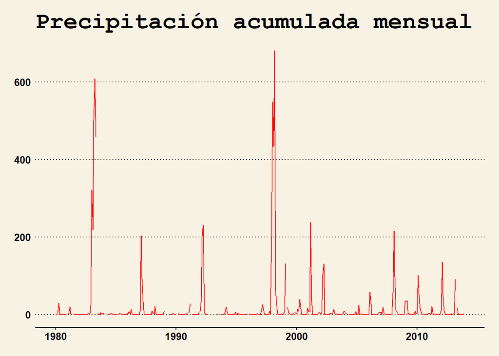

```r
library(ggplot2)
library(ggthemes)
ggplot(pp_acmes, aes(fecha, pp_m)) +
  geom_line(color = "red")+
  labs(y="Precipitación (mm)", x = "Años")+
  ggtitle("Precipitación acumulada mensual")+
  theme_wsj(base_size = 10)
```

**c)** Determine la cantidad de missing values de la serie de tiempo a paso mensual.

```r
pp_mes<- pp_acmes %>% dplyr::filter(is.na(pp_m)) %>% nrow()
pp_mes
```

```
## [1] 26
```

**d)** Cree una función que calcule, a partir de los datos de precipitación mensual, la climatología (Ene-Dic) para el período 1980-2010.

```r
Climatologia <-function(Amin,Amax){
  dplyr::filter(pp_acmes,str_sub(fecha,1,4) >= Amin & str_sub(fecha,1,4) <=Amax)  %>%
  mutate(mes = str_sub(fecha,6,7)) %>%
  group_by(mes) %>%
  summarize(pp_m = mean(pp_m,na.rm = T)) %>%
  mutate(mes = month.abb) %>%
  mutate(mes = factor(mes,levels=month.abb))
}
```

```r
Climatologia(1980,2010)
```

```
## # A tibble: 12 x 2
##    mes     pp_m
##    <fct>  <dbl>
##  1 Jan   36.0
##  2 Feb   56.3
##  3 Mar   81.4
##  4 Apr   48.8
##  5 May   18.8
##  6 Jun    0.393
##  7 Jul    0.235
##  8 Aug    0.183
##  9 Sep    0.177
## 10 Oct    1.23
## 11 Nov    1.11
## 12 Dec   10.2
```

Por consiguiente, se procede a plotearlo:

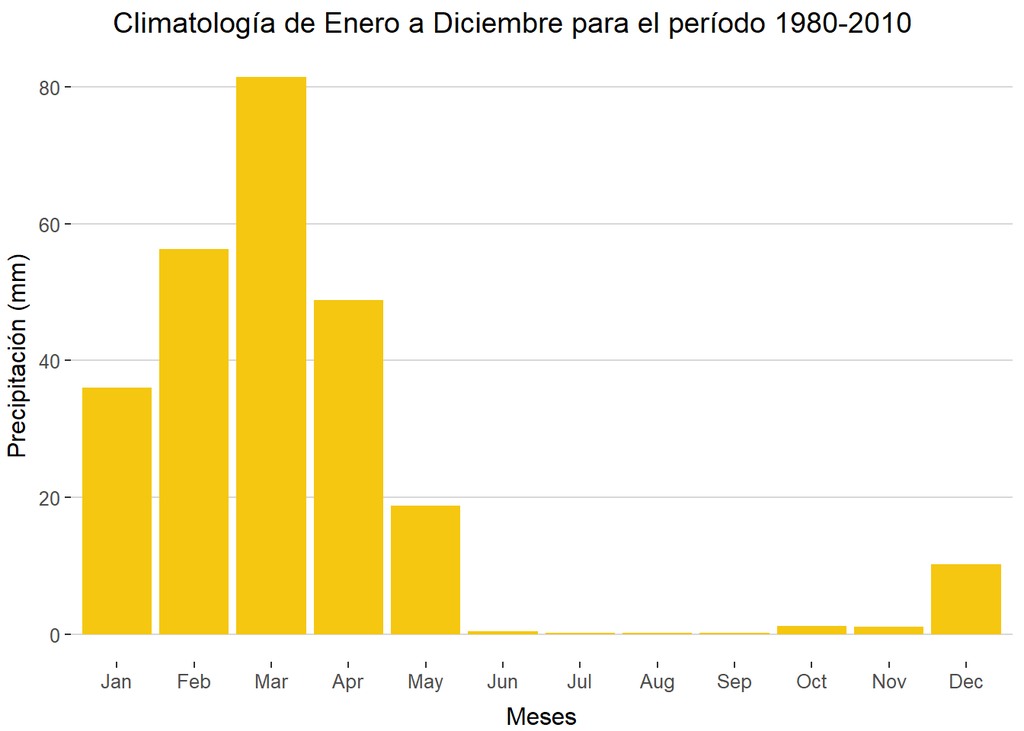

```r
ggplot(Climatologia(1980,2010), aes(mes, pp_m)) +
  geom_bar(stat = "identity", fill = "#F5C710")+
  scale_x_discrete(labels = month.abb)+
  labs(y="Precipitación (mm)", x = "Meses")+
  ggtitle("Climatología de Enero a Diciembre para el período 1980-2010")+
  theme(plot.title = element_text(vjust = 1, hjust = 0.3))+
  theme(axis.title.y = element_text(vjust = 2))+
  theme(axis.title.x = element_text(vjust = -1))+
  theme_hc()
```

*Descripción: El gráfico representa un histograma en barras en función de la precipitación y el periódo en meses, desde el año 1980 hasta el año 2010 se promedio cada mes para obtener los resultados, los valores de cada mes idéntico de todos los años para representar los periódos en la que se concentró la mayor cantidad de precipitación, los valores son mayores en los primeros meses del año que coincide con los meses de verano donde en la región son las épocas donde más llueve, siendo marzo el mas alto y los meses de invierno teniendo los menores valores.*

```r
PPPromedioAnual <- function(Pmin,Pmax){
  PPPromedioAnual1<- dplyr::filter(pp_acmes,str_sub(fecha,1,4) >=Pmin & str_sub(fecha,1,4) <=Pmax)  %>%
    group_by(fecha = str_sub(fecha,1,4)) %>%
    summarize(pp_m = sum(pp_m,na.rm = T))
  return(PPPromedioAnual1)}
```

```r
View(PPPromedioAnual(1980,2010))
```

Se procederá a plotear:

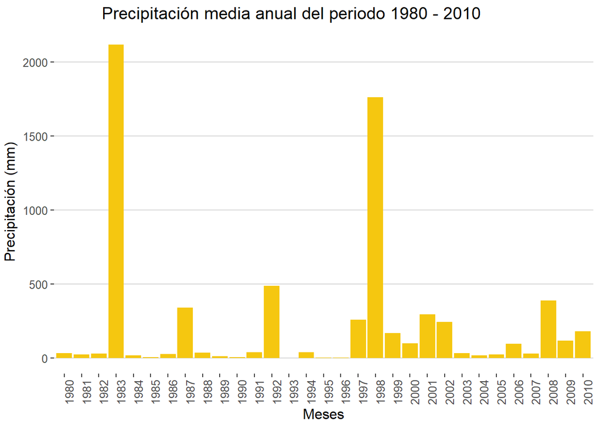

```r
ggplot(PPPromedioAnual(1980,2010), aes(fecha, pp_m)) +
  geom_bar(stat = "identity", fill = "#F5C710")+
  labs(y="Precipitación (mm)", x = "Meses")+
  ggtitle("Precipitación media anual del periodo 1980 - 2010")+
  theme(plot.title = element_text(vjust = 1, hjust = 0.3))+
  theme(axis.title.y = element_text(vjust = 2))+
  theme(axis.text.x = element_text(angle = 90))+
  theme_hc()
```

*Descripción: El gráfico representa un histograma en barras en función de la precipitación y el periódo anual,para esto se presento la cantidad de precipitación registradas anuales durante los años de 1980 al 2010 donde se registró la mayor cantidad de precipitación en el año de 1982-1983, en ese tiempo ocurrió uno de los peores Fenómenos del Niño en la historia lloviendo desde Dicimebre de 1982 hasta Junio del año 1983, debido a eso representa una de las mayores cantidades de precipitación registradas seguido del periódo de 1997 a 1998 con un caso similar pero en menor intensidad, siendo los registros más anómals, los demás periodos siendo mas moderados en cuestión a la cantidad de precipitación registradas.*

```r
pp_month<- pp_acmes %>% mutate(fecha = as.Date(sprintf("%1$s-01",fecha))) %>%
  dplyr::filter(fecha >= as.Date("1980-01-01") & fecha <= as.Date("2010-12-31")) %>%
  mutate( mes = str_sub(fecha,6,7))
```

Para graficar, se utilizo la librería `ggplot2` en la cuál ingresaremos los parámetros.

```r
A<-ggplot(dplyr::filter(pp_month, fecha >= "1980-01-01" & fecha <= "2013-12-31"))+
  geom_boxplot( aes(x=mes,y=pp_m, color = mes))+
  ggtitle("Valores mensuales (Enero-Diciembre) para el período 1980-2013")+
  xlab("Meses") + ylab("Precipitación (mm)") +
  theme_igray()+
  scale_x_discrete(labels = month.abb,name="Meses")+
  scale_color_discrete(labels= month.abb,name="Meses")
```

[figure not shown]

```r
plot(A)
```